# 3888_covid-A_6_R_Amber

Amber

4/11/2022

## EDA

AIM: Does vaccination reduce death rated in the population of developing countries compared to developed countries

As you can see from the chart below, Australia has fewer deaths for the same level of vaccination than Malaysia. It can therefore be considered whether vaccination has reduced mortality in the Australian population compared to Malaysia.

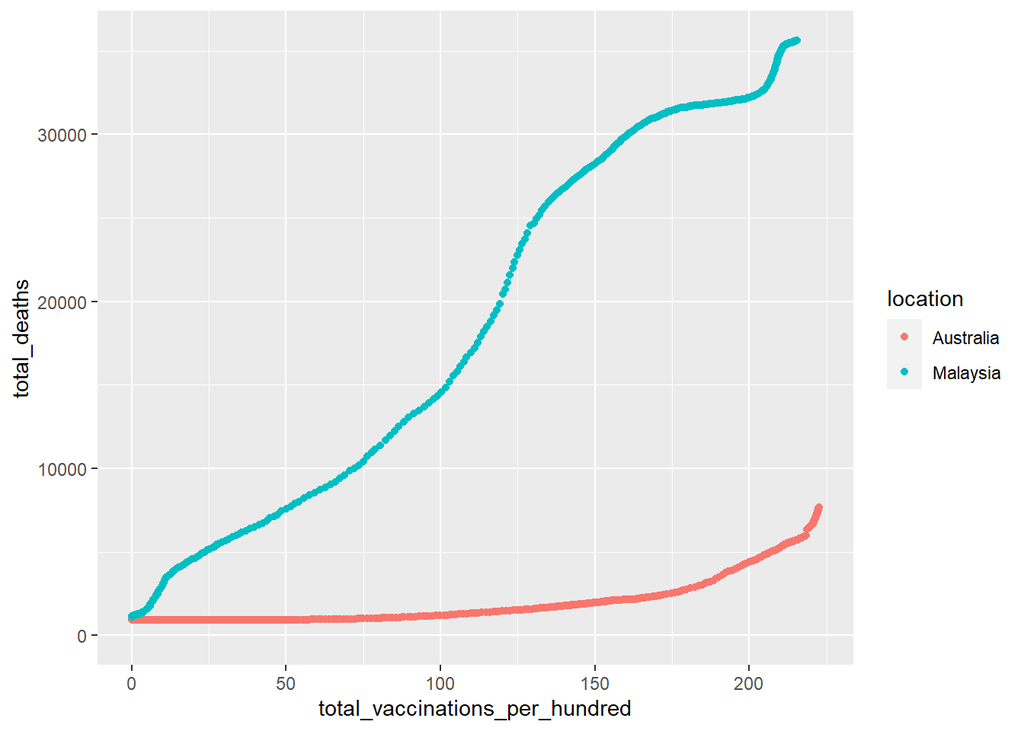

```r
# data <- read.csv("data/owid-covid-data-160222.csv")
data <- read.csv("https://github.com/owid/covid-19-data/raw/master/public/data/owid-covid-data.csv")

# data <- read.csv("owid-covid-data.csv")

# select Australia and Malaysia data
data <- rbind(data[data$location == 'Australia',],
              data[data$location == 'Malaysia',])


library(ggplot2)
ggplot(data = data) +
  geom_point(aes(x=total_vaccinations_per_hundred, y =total_deaths,color = location))
```

We first filter out suitable countries that represents developing countries and developed countries, as we can see from the view() function, only Australia and Malaysia has a suitable human development index.

```r
developed_countries = data %>%
  filter(human_development_index >= 0.854)

developing_countries = data %>% #Filtering countries which are developing and already developed by their hdi(human development index)
  filter(human_development_index < 0.854)
developing_countries = subset(developing_countries, location!="World")

# view(developed_countries)
# view(developing_countries)
```

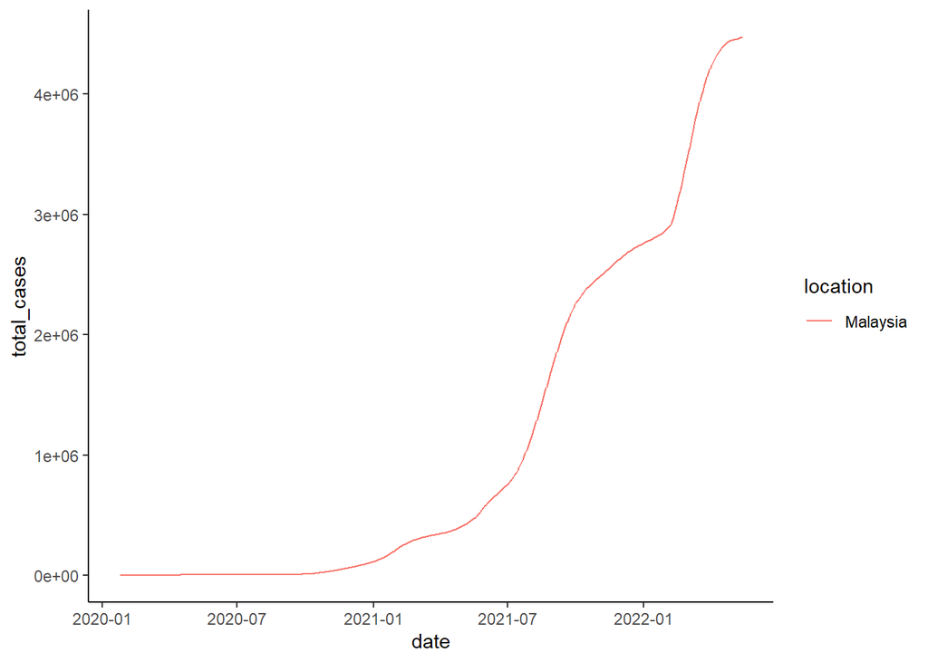

```r
Malaysia <- data[data$location == 'Malaysia',]
Malaysia$date <- as.Date(Malaysia$date)


ggplot(data = Malaysia) +
    geom_line(aes(x=date, y =total_cases,color = location)) +
    theme_classic()
```

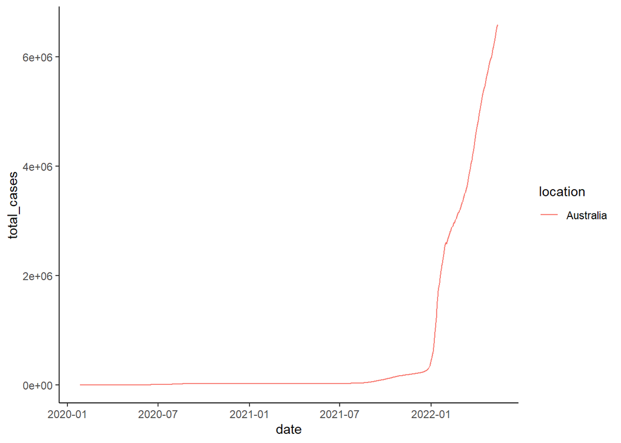

```r
Australia <- data[data$location == 'Australia',]
Australia$date <- as.Date(Australia$date)


ggplot(data = Australia) +
    geom_line(aes(x=date, y =total_cases,color = location)) +
    theme_classic()
```

## model: Time series model of the number of confirmed cases in Australia

This part will establish a time series model for the total number of confirmed cases in Australia. First, a sample of The Australian region was selected and a trend chart of the total number of confirmations was drawn. As can be seen from the figure, there is an overall upward trend in the change time series.

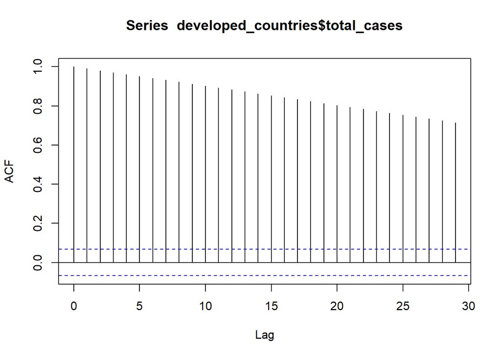

```r
acf(developed_countries$total_cases)
```

As can be seen from the automatic grading of arima model, the most suitable model is arima (0,2,1).

Trends in the number of people diagnosed in developed countries over the next 30 days based on the ARIMA model. As can be seen from the graph, the number of confirmed cases is still on the rise.

```r
fit <- auto.arima(developed_countries$total_cases)
forecast(fit, 30)
```

```
##     Point Forecast   Lo 80   Hi 80   Lo 95   Hi 95
## 841        6636393 6628161 6644626 6623802 6648984
## 842        6682721 6667820 6697621 6659931 6705510
## 843        6729048 6706735 6751360 6694924 6763172
## 844        6775375 6744875 6805876 6728729 6822022
## 845        6821702 6782276 6861128 6761406 6881999
## 846        6868030 6818986 6917073 6793024 6943035
## 847        6914357 6855044 6973669 6823646 7005068
## 848        6960684 6890487 7030881 6853327 7068041
## 849        7007011 6925346 7088676 6882116 7131907
## 850        7053339 6959649 7147028 6910053 7196625
## 851        7099666 6993419 7205913 6937175 7262157
## 852        7145993 7026677 7265309 6963515 7328471
## 853        7192320 7059443 7325198 6989102 7395539
## 854        7238648 7091733 7385562 7013961 7463334
```

[output cut: 16 more lines]

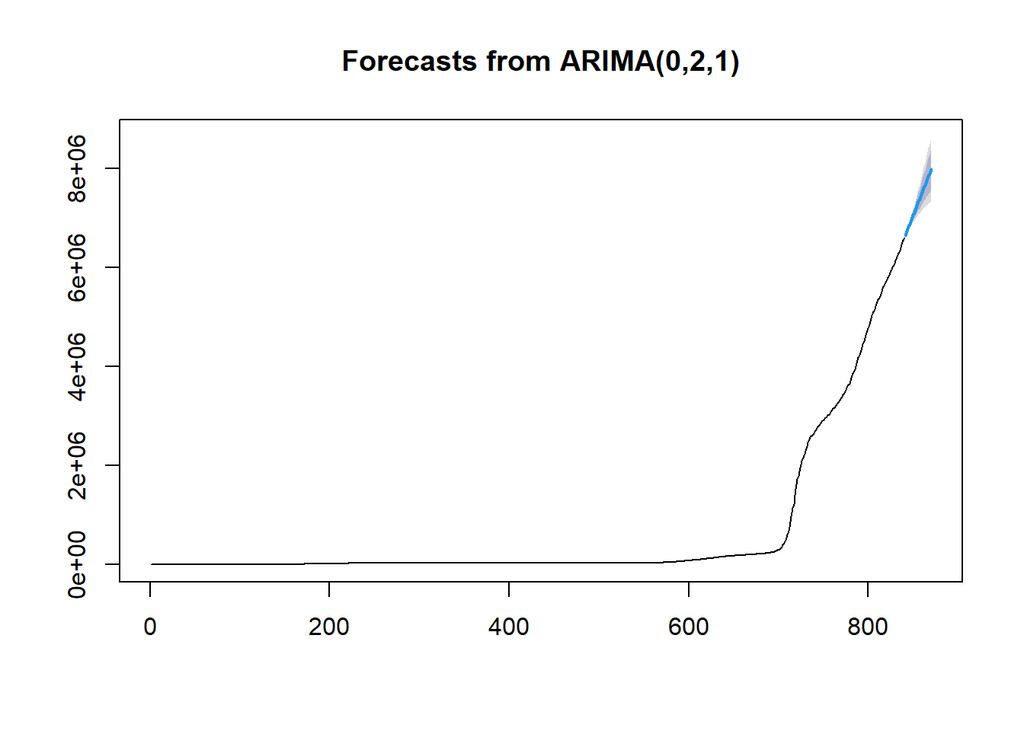

```r
plot(forecast(fit, 30))
```

Trends in the number of people diagnosed in developing countries over the next 30 days based on the ARIMA model. As can be seen from the graph, the number of confirmed cases is still on the rise.

```r
fit <- auto.arima(developing_countries$total_cases)
forecast(fit, 30)
```

```
##     Point Forecast   Lo 80   Hi 80   Lo 95   Hi 95
## 843        4478447 4477313 4479582 4476712 4480182
## 844        4481002 4478522 4483482 4477209 4484795
## 845        4483337 4479350 4487323 4477240 4489433
## 846        4485416 4479838 4490994 4476885 4493947
## 847        4487389 4480116 4494662 4476266 4498512
## 848        4489474 4480332 4498616 4475493 4503456
## 849        4491803 4480549 4503058 4474592 4509015
## 850        4494329 4480708 4507950 4473498 4515160
## 851        4496865 4480680 4513050 4472112 4521617
## 852        4499223 4480365 4518081 4470382 4528064
## 853        4501351 4479771 4522930 4468348 4534353
## 854        4503360 4479015 4527705 4466128 4540592
## 855        4505445 4478244 4532646 4463845 4547045
## 856        4507739 4477534 4537943 4461545 4553933
```

[output cut: 16 more lines]

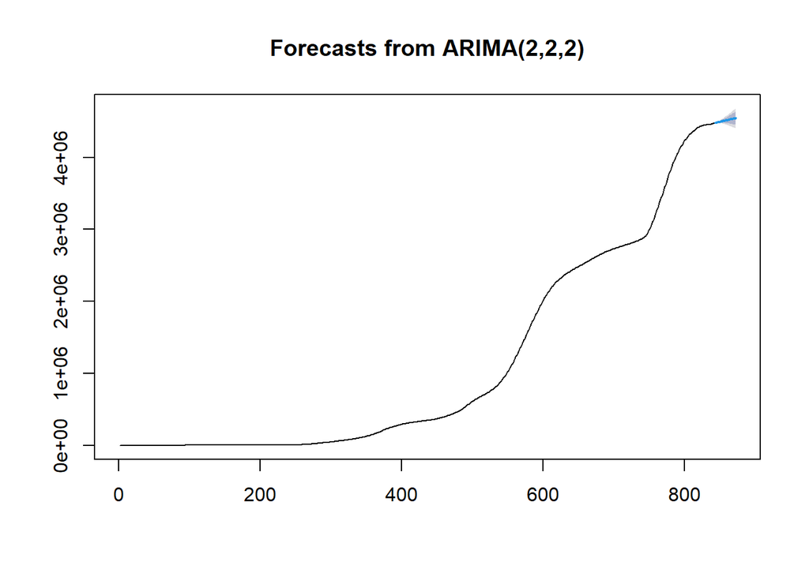

```r
plot(forecast(fit, 30))
```